# Improving Actuarial Communication

**Jason Ash** FSA, CERA, MAAA

**Zachary Brown** CFA, FRM, PRM

*August 28, 2018*

[figure not shown]

*About the speaker*

[figure not shown]

Jason Ash is the founder of Ash Analytics, an actuarial consulting business focused within the fintech and insurtech space.

Jason is a former consulting actuary at Milliman with a background in financial risk management. He was an analytics manager at LendingClub, a fintech company that operates a peer-to-peer credit marketplace, and he has worked at an early stage insurtech startup based in San Francisco.

Jason can be reached at jason@ashanalytics.com, or via www.jtash.com

*Agenda*

### Motivations for visual communication

Defining properties of an effective visualization

### Methods for presenting data

Python visualization libraries you can use immediately  
Python-powered, reproducible jupyter notebooks

*Presentation*

The presentation itself demonstrates new and exciting visual technology powered by jupyter notebooks and `reveal.js`. It combines code, charts, images, video, and an interactive slide format that is best viewed in a web browser.

# Motivations for visual communication

"As the knowledge of mankind increases, and transactions multiply, it becomes more and more desirable to abbreviate and facilitate the modes of conveying information..."

"Men of high rank, or active business, can only pay attention to outlines… It is hoped that, **with the Assistance of these Charts, such information will be got without the fatigue and trouble of studying the particulars.**"

--William Playfair

*Excel*

### `Alt` + `n` + `n` = chart

[figure not shown]

*Python*

### `pandas` - the premier data science and visualization library

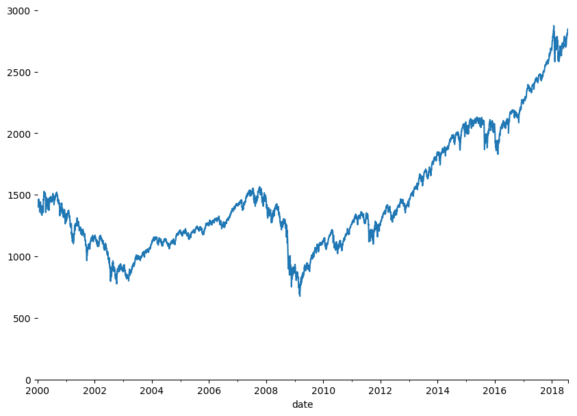

```python
import pandas as pd

spx = pd.read_csv('data/spx.csv',index_col=0,parse_dates=[0])
spx.plot(legend=False,ylim=(0,3000));
```

*Motivations for visual communication*

**Goal**: to quickly understand large, complex data

**Goal**: use effective visual design to communicate useful insights to your audience

*Example*

Communicating **data** vs. **perspective**

[figure not shown]

Susie Lu, www.susielu.com

[figure not shown]

Susie Lu, www.susielu.com

*Example*

"Above all, show the data" --Edward Tufte

[figure not shown]

New York Times, www.nytimes.com

[figure not shown]

New York Times, www.nytimes.com

[figure not shown]

New York Times, www.nytimes.com

[figure not shown]

New York Times, www.nytimes.com

[figure not shown]

New York Times, www.nytimes.com

[figure not shown]

New York Times, www.nytimes.com

[figure not shown]

New York Times, www.nytimes.com

"Above all, show the data" --Edward Tufte

*... but remember*

Most data is generated by inherently subjective processes

It can be influenced by societal norms and biases

Sometimes the most important insights are revealed by the absence of data.

[figure not shown]

Wall Street Journal, www.wsj.com

[figure not shown]

Pew Research Center, www.pewsocialtrends.org

*Motivations for visual communication*

**Understand your data** - emphasis on speed, observing trends, personal consumption

**Communicate your data** - emphasis on effective design, sharing a perspective, being aware of data limitations, and influencing an audience

*Properties of an effective visualization*

**Explicit** - show data clearly, but understand its limitations, label directly when possible

**Implicit** - intentional design, clear perspective, beware of defaults

# Methods for presenting data

*Methods for presenting data*

**Technology**

Python and the `pandas` library: a "supercharged excel"  
Jupyter notebooks: shareable, reproducible analytics  
Open source data and code

**Design**

Emphasizing perspective, context, and clear messaging

"The more sophisticated science becomes, the harder it is to communicate results."

"Scientific results today are as often as not found with the help of computers. That’s because the ideas are complex, dynamic, hard to grab ahold of in your mind’s eye. And yet by far the most popular tool we have for communicating these results is the PDF—literally a simulation of a piece of paper. Maybe we can do better."

--"The Scientific Paper Is Obsolete," The Atlantic

*Technology*

[figure not shown]

*Jupyter Notebook*

[figure not shown]

Shareable, source-controlled document viewed in a web browser

Open source, free to use, continually developed and improved

Available for nearly every programming language

*Example*

Follow your charts

```python
# hedging example
import numpy as np
np.random.seed(42)

d = pd.DatetimeIndex(start=pd.datetime(2015,1,1),end=pd.datetime(2018,8,1),freq='w')
unhedged = np.random.normal(0.003,0.05,d.shape[0])
hedged = np.random.normal(0.001,0.005,d.shape[0])
```

```python
print(d[:12])
```

```
DatetimeIndex(['2015-01-04', '2015-01-11', '2015-01-18', '2015-01-25',
               '2015-02-01', '2015-02-08', '2015-02-15', '2015-02-22',
               '2015-03-01', '2015-03-08', '2015-03-15', '2015-03-22'],
              dtype='datetime64[ns]', freq='W-SUN')
```

```python
print(hedged[:18])
```

```
[ 0.00063586 -0.00323397 -0.00657424 -0.00123257  0.00528199  0.00207047
 -0.00522869  0.0018659   0.00292659 -0.00341929  0.00176863  0.00129104
 -0.00471485  0.00278894  0.00380392  0.00641526  0.00626901 -0.00588835]
```

[figure not shown]

*Follow your charts*

Important to document methodology, data sources, anomalies, etc.

Ideal to understand your audience, refine your perspective, set context

[figure not shown]

*How to get started*

[figure not shown]

One package that includes python, jupyter notebooks, and useful libraries

Start by importing a `.csv` and tinker with excel-like functionality in `pandas`

Explore online resources: [github](https://www.github.com), [stack overflow](https://stackoverflow.com/questions/tagged/pandas)

*Example*

Open data from fivethirtyeight

Hundreds of datasets used in analytic journalism

[figure not shown]

**Understand** your data

```python
url = 'https://raw.githubusercontent.com/fivethirtyeight/data/master/daily-show-guests/daily_show_guests.csv'

guests = pd.read_csv(url,parse_dates=['Show'])
guests.columns = ['year','occupation','episode','group','name']
guests.group = guests.group.str.title()
guests.head(10)
```

|  | year | occupation | episode | group | name |
| --- | --- | --- | --- | --- | --- |
| 0 | 1999 | actor | 1999-01-11 | Acting | Michael J. Fox |
| 1 | 1999 | Comedian | 1999-01-12 | Comedy | Sandra Bernhard |
| 2 | 1999 | television actress | 1999-01-13 | Acting | Tracey Ullman |
| 3 | 1999 | film actress | 1999-01-14 | Acting | Gillian Anderson |
| 4 | 1999 | actor | 1999-01-18 | Acting | David Alan Grier |
| 5 | 1999 | actor | 1999-01-19 | Acting | William Baldwin |
| 6 | 1999 | Singer-lyricist | 1999-01-20 | Musician | Michael Stipe |
| 7 | 1999 | model | 1999-01-21 | Media | Carmen Electra |
| 8 | 1999 | actor | 1999-01-25 | Acting | Matthew Lillard |
| 9 | 1999 | stand-up comedian | 1999-01-26 | Comedy | David Cross |

```
plt.style.use('fivethirtyeight')
fig, ax = plt.subplots()
plt.suptitle("Who got to be on 'The Daily Show'?",fontsize=24,ha='left',x=0.02)
plt.title('Occupation of guests, by year',color='0.4',fontsize=18,ha='left',x=-0.065)

# data
out.plot(ax=ax,legend=False,color=['#0099ff','#990099','#ff3333'])

# annotation
ax.annotate('Acting, Comedy & Music',(2001,0.8),color='#0099ff',fontsize=18,fontweight='bold')
ax.annotate('Media',(2007.5,0.52),color='#990099',fontsize=18,fontweight='bold')
ax.annotate('Government and Politics',(2008.5,0.05),color='#ff3333',fontsize=18,fontweight='bold')

# chart style
ax.axhline(0,color='0.6',lw=2.5)
ax.set_ylim(-0.05,1.05)
ax.set_xlim(1998,2016)
ax.set_xticks([2000,2004,2008,2012])
ax.set_xticklabels(['2000',"'04","'08","'12"])
ax.set_yticks([0,0.25,0.5,0.75,1])
ax.set_yticklabels(['0%','25%','50%','75%','100%'])

plt.show()
```

[figure not shown]

**Communicate** your data

[figure not shown]

*Example*

### Fivethirtyeight Riddler

Two weekly puzzles based on math, probability, and logic

Thousands of respondents, only a handful of featured solutions

[figure not shown]

*Riddler hot potato*

A class of 30 children is playing a game where they all stand in a circle along with their teacher. The teacher is holding two things: a coin and a potato.

The game progresses like this: The teacher tosses the coin. Whoever holds the potato passes it to the left if the coin comes up heads and to the right if the coin comes up tails. The game ends when every child except one has held the potato, and the one who hasn’t is declared the winner.

How do a child’s chances of winning change depending on where they are in the circle? In other words, what is each child’s win probability?

**Understand** your data

```python
import random

def model(trials, students=30):

    for _ in range(trials):

        s = [0] + [1]*students
        i = 0

        while sum(s) > 1:
            i += random.choice([-1,1])
            s[i] = 0

        yield s.index(1)
```

```python
trials = 100000
results = np.array(list(model(trials)))
```

```python
out = np.histogram(results,bins=range(1,32),normed=True)[0]
out
```

```
array([ 0.03313,  0.03346,  0.03447,  0.03304,  0.03361,  0.03251,
        0.03395,  0.0331 ,  0.0334 ,  0.03253,  0.03321,  0.03345,
        0.03331,  0.03452,  0.03215,  0.03176,  0.03364,  0.03297,
        0.03354,  0.03215,  0.03383,  0.03275,  0.03309,  0.033  ,
        0.03379,  0.03376,  0.03397,  0.03432,  0.03446,  0.03313])
```

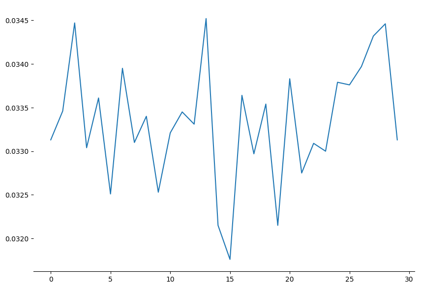

```python
fig, ax = plt.subplots()
plt.plot(np.arange(out.shape[0]),out);
```

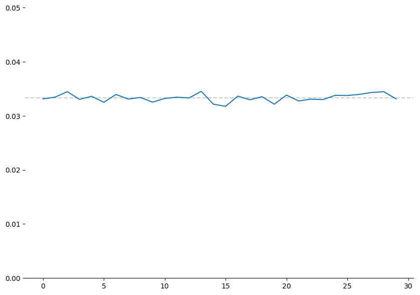

```python
fig, ax = plt.subplots()
ax.set_ylim(0,0.05)
ax.axhline(1/30,ls='--',c='0.8')
plt.plot(np.arange(out.shape[0]),out);
```

**Communicate** your data

A class of 30 children is playing a game where they all **stand in a circle** along with their teacher. The teacher is holding two things: a coin and a potato.

The game progresses like this: The teacher tosses the coin. **Whoever holds the potato passes it to the left if the coin comes up heads and to the right if the coin comes up tails.** The game ends when every child except one has held the potato, and the one who hasn’t is declared the winner.

How do a child’s chances of winning change depending on where they are in the circle? In other words, **what is each child’s win probability?**

**Communicate** your data

**Design**: Portray game mechanics in addition to the data

**Perspective**: equality of outcomes is the unexpected result: highlight this

**Audience**: emphasize creativity while preserving accuracy

[figure not shown]

```
fig, ax = plt.subplots(1,2,figsize=(12,6),subplot_kw=dict(projection='polar'))
plt.tight_layout()

# plot data
points = np.deg2rad(np.linspace(0,360,31,endpoint=False))

ax[0].plot(points[1:],p,alpha=0.9)
ax[0].fill_between(points[1:],p,0,alpha=0.1)
ax[1].plot(points[path],np.linspace(1,0.25,path.shape[0]),alpha=0.9)
ax[1].axvline(points[22],0.25,1,color='darkgreen',alpha=0.8)

# domain and range
ax[0].set_ylim(0.031,0.034)
ax[0].set_yticks([round(p.min(),6),round(p.max(),6)])
ax[0].set_yticklabels([])
ax[1].set_ylim(0,1)
ax[1].set_yticks([])

# annotations
kwargs = dict(ha='center',color='0.3',style='italic',size=11)
ax[0].annotate('minimum: {:,.2%}'.format(p.min()),xy=(np.pi,p.min()*0.99),**kwargs)
ax[0].annotate('maximum: {:,.2%}'.format(p.max()),xy=(np.pi,p.max()*1.003),**kwargs)
ax[1].annotate('winner!',xy=(points[22]-0.05,0.9),color='darkgreen',size=14,alpha=0.8)

# style, circumference labels, 'teacher' label at the bottom
for i in range(2):
    ax[i].spines['polar'].set_visible(False)
    ax[i].xaxis.grid(True,color='0.95')
    ax[i].set_xticks(points)
    ax[i].set_xticklabels(['teacher'] + list(range(1,31)),size=14,color='0.4')
    ax[i].set_theta_offset(-np.pi/2)

plt.show()
```

[figure not shown]

# Final Thoughts

**Understand your data**  
Find ways to use new tools for familiar tasks, e.g. Python, jupyter notebooks instead of excel. It takes less time than you think.

**Communicate your data**  
For each visual you create, find the opportunity to communicate a perspective or justify an action, rather than simply showing the data